# Temperature Dependance of Disease Vector Traits

There are three main objectives to this project: the collection and homogenisation of separate datasets, the analysis of the structure and quality of the unified dataset and an analysis of the variation in thermal response between traits, genus and species.

```r
library(ggplot2)
# library(plyr)
library(polynom)
library(AICcmodavg)
library(gridExtra)
setwd("C:\\Users\\smytmc\\Desktop\\Own work\\Final year project work\\Code")
data <- read.csv('collected_data (mod8, analysis).csv') # raw data
```

# 1 Polynomial Regressions for Traits Data

Creates scatter plots of all different types of traits and then runs 1st, 2nd and 3rd order polynomial regressions through the data.

## 1.1 Polynomial Regression Plots

Test Plot

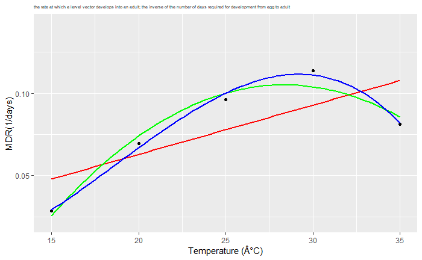

```r
count <- 2
    count_sub <- subset(data, data$DataSeriesID == count)
    ggplot(count_sub, aes(x = AmbientTemp, y = TraitValueSI)) +
      geom_point() +
        ylim(0.75*min(count_sub$TraitValueSI), 1.25*max(count_sub$TraitValueSI)) +
        theme(plot.title = element_text(size = rel(0.5))) +
        xlab("Temperature (Â°C)") +
        ylab(paste(count_sub$Trait, "(", count_sub$TraitUnitSI, ")", sep="")) +
        ggtitle(count_sub$TraitDef) +
        stat_smooth(method = "lm", se = TRUE, fill = NA, formula = y ~ x, colour = "red") +
        stat_smooth(method = "lm", se = TRUE, fill = NA, formula = y ~ poly(x, 2, raw = TRUE), colour = "green") +
        stat_smooth(method = "lm", se = TRUE, fill = NA, formula = y ~ poly(x, 3, raw = TRUE), colour = "blue")
```

Plots all and saves results

```r
setwd("./Reg_plots")
```

[output not shown]

```r
for(count in unique(data$DataSeriesID)){
# for(count in seq(1,10)){
    # count <- 1  # set count manually and run within for loop to test individual plots
    count_sub <- subset(data, data$DataSeriesID == count)
    png(paste("Plot", count, "regressions.png"), width = 2000, height =2000, res = 300)
    a <- ggplot(count_sub, aes(x = AmbientTemp, y = TraitValueSI))
    a <- a + geom_point() +
        ylim(0.75*min(count_sub$TraitValueSI), 1.25*max(count_sub$TraitValueSI)) +
        theme(plot.title = element_text(size = rel(0.5))) +
        xlab("Temperature (Â°C)") +
        ylab(paste(count_sub$Trait, "(", count_sub$TraitUnitSI, ")", sep="")) +
        ggtitle(count_sub$TraitDef) +
        stat_smooth(method = "lm", se = TRUE, fill = NA, formula = y ~ x, colour = "red") +
        stat_smooth(method = "lm", se = TRUE, fill = NA, formula = y ~ poly(x, 2, raw = TRUE), colour = "green") +
        stat_smooth(method = "lm", se = TRUE, fill = NA, formula = y ~ poly(x, 3, raw = TRUE), colour = "blue")
    plot(a)
    dev.off()
}
setwd("..")
```

## 1.2 Polynomial Regression Model Creation and selection

For each trait a 1st, 2nd and 3rd order polynomial regression is run. The best model for each trait is selected based on the smallest AICc (Akaike information criterion, corrected for small sample size).

For each set of trait measurments the key information like the minimum, maximum and description is collected in the results table.

Information about the best model is also extracted, the intercept points with the x axis signify the points at which trait activity reaches zero and hence is the minimum and maximum operating temperature for the trait. And the highest activity inflection point is the trait’s optimal temperature.

```r
InverseSets <- c(54, 59, 60, 61, 72, seq(76, 86), 114, 116, 117)  # add the dataseriesID for data that has inverse relationship e.g. mortality
Results <- data.frame() # initlialise results data frame
for(count in unique(data$DataSeriesID)){
    # count <- 75  # set count manually and run within for loop to test individual plots
    count_sub <- subset(data, data$DataSeriesID == count)
    reg1 <- lm(count_sub$TraitValueSI ~ count_sub$AmbientTemp)
    reg2 <- lm(count_sub$TraitValueSI ~ poly(count_sub$AmbientTemp, 2, raw = TRUE))
    reg3 <- lm(count_sub$TraitValueSI ~ poly(count_sub$AmbientTemp, 3, raw = TRUE))
    models <- list(reg1, reg2, reg3)
    ModAICc <- c(AICc(reg1), AICc(reg2), AICc(reg3))  # evaluates AIC and stores as vectors in ModAIC
    minAICc <- which(ModAICc == min(ModAICc))  # min(ModAIC2)[1] (?) finds the location of the minimum value of AIC in ModAIC, e.g. number 1, 2 or 3
    BestModel <- models[[minAICc[1]]]  # selects model based on location dictated by minAIC
    Results[count, "Trait"] <- count_sub$Trait[1]
    Results[count, "Trait Definition"] <- count_sub$TraitDef[1]
    Results[count, "Poly Order"] <- minAICc[1] # gives the order of the polynomial
    f <- summary(BestModel)$fstatistic
    Results[count, "p-value for F-stat"] <- pf(f[1], f[2], f[3], lower.tail = FALSE) # calculate f-statistic p-value
    Results[count, "F-statistic"] <- f[1] # f-statistic
    ifelse(is.infinite(ModAICc[minAICc[1]]), Results[count, "AICc"] <- "NegInf", Results[count, "AICc"] <- ModAICc[minAICc[1]])
    Results[count, "No. Data Points"] <- length(count_sub$TraitValueSI)
    Results[count, "No. Unique Temperatures"] <- length(unique(count_sub$AmbientTemp))
    Results[count, "R squared"] <- summary(BestModel)$r.squared
    Results[count, "Adj R squared"] <- summary(BestModel)$adj.r.squared
    Results[count, "Vector Genus"] <- count_sub$VectorGenus[1]
    Results[count, "Vector Species"] <- count_sub$VectorSpecies[1]
    Results[count, "Min Measured Temp"] <- min(count_sub$AmbientTemp)
    Results[count, "Max Measured Temp"] <- max(count_sub$AmbientTemp)
    Results[count, "Range Measured Temp"] <- max(count_sub$AmbientTemp) - min(count_sub$AmbientTemp)

    PolyMod <- polynomial(coef(BestModel))
    modSta <- summary(PolyMod)$stationaryPoints
    if (count %in% InverseSets){
        # for multiple values takes mean, finds the corresponding temperatures whose trait value is the maximum
        Results[count, "Optimal Measured Temp"] <- mean(count_sub$AmbientTemp[which(count_sub$TraitValueSI == min(count_sub$TraitValueSI))])
        if(length(modSta) == 0){
            Results[count, "Optimal Estimated Temp"] <- NA
        } else if (is.infinite(modSta) | is.complex(modSta)){
            Results[count, "Optimal Estimated Temp"] <- NA
        } else {
            modPre <- predict(PolyMod, modSta)
            LocMinPre <- which(modPre == min(modPre))
            minSta <- modSta[[LocMinPre]]
            Results[count, "Optimal Estimated Temp"] <- minSta
        }
    } else {
        Results[count, "Optimal Measured Temp"] <- mean(count_sub$AmbientTemp[which(count_sub$TraitValueSI == max(count_sub$TraitValueSI))])
        if(length(modSta) == 0){
            Results[count, "Optimal Estimated Temp"] <- NA
        } else if (is.infinite(modSta) | is.complex(modSta)){
            Results[count, "Optimal Estimated Temp"] <- NA
        } else {
            modPre <- predict(PolyMod, modSta)
            LocMaxPre <- which(modPre == max(modPre))
            maxSta <- modSta[[LocMaxPre]]
            Results[count, "Optimal Estimated Temp"] <- maxSta
        }
    }
    PolyZeroPre <- summary(PolyMod)$zeros
    if(length(PolyZeroPre) < 2){
        Results[count, "Min Estimated Temp"] <- NA
        Results[count, "Max Estimated Temp"] <- NA
    } else if (is.infinite(PolyZeroPre) | is.complex(PolyZeroPre)){
        Results[count, "Min Estimated Temp"] <- NA
        Results[count, "Max Estimated Temp"] <- NA
    } else {
        Results[count, "Min Estimated Temp"] <- min(PolyZeroPre)
        Results[count, "Max Estimated Temp"] <- max(PolyZeroPre)
    }
    # PolyMax <- which(RangeMin <= PolyMaxPre & PolyMaxPre <= RangeMax) # remove outside range
    # PolyMax <- subset(PolyMaxPre, RangeMin <= PolyMaxPre & PolyMaxPre <= RangeMax)
    # if(length(PolyMaxPre) == 0 | is.infinite(PolyMaxPre) | is.complex(PolyMaxPre)){
    #   Results[count, "Optimal Estimated Temp"] <- NA
    # } else {
    #   Results[count, "Optimal Estimated Temp"] <- max(PolyMaxPre)
    # }
}
write.csv(Results, "Results.csv")
head(Results, 10)
```

|  | Trait | Trait Definition | Poly Order | p-value for F-stat | F-statistic | AICc | No. Data Points | No. Unique Temperatures | R squared | Adj R squared | Vector Genus | Vector Species | Min Measured Temp | Max Measured Temp | Range Measured Temp | Optimal Measured Temp | Optimal Estimated Temp | Min Estimated Temp | Max Estimated Temp |
| --- | --- | --- | --- | --- | --- | --- | --- | --- | --- | --- | --- | --- | --- | --- | --- | --- | --- | --- | --- |
| 1 | pEA | probability that a vector survives from the egg stage to the adult stage | 2 | 0.0213120 | 9.154411 | 88.3745596313126 | 8 | 8 | 0.7854889 | 0.6996845 | Aedes | albopictus | 5 | 40 | 35 | 20 | 22.78508 | 6.667082 | 38.90307 |
| 2 | MDR | the rate at which a larval vector develops into an adult; the inverse of the number of days required for development from egg to adult | 3 | 0.1077739 | 46.078651 | -95.9897269931324 | 5 | 5 | 0.9928179 | 0.9712718 | Aedes | albopictus | 15 | 35 | 20 | 30 | 29.21390 | NA | NA |
| 3 | p | the average daily probability of an adult vector surviving, equal to the exponential of negative mu, the daily mortality rate, assuming a constant mortality rate throughout the adult vector lifespan | 2 | NaN | NaN | NegInf | 3 | 3 | 1.0000000 | NaN | Aedes | albopictus | 22 | 26 | 4 | 22 | 26.15294 | NA | NA |
| 4 | MDR | the rate at which a larval vector develops into an adult; the inverse of the number of days required for development from egg to adult | 2 | NaN | NaN | NegInf | 3 | 3 | 1.0000000 | NaN | Aedes | albopictus | 22 | 30 | 8 | 30 | 36.01860 | 5.817105 | 66.22010 |
| 5 | p | the average daily probability of an adult vector surviving, equal to the exponential of negative mu, the daily mortality rate, assuming a constant mortality rate throughout the adult vector lifespan | 2 | NaN | NaN | NegInf | 3 | 3 | 1.0000000 | NaN | Aedes | albopictus | 22 | 30 | 8 | 22 | 21.74910 | -31.543406 | 75.04161 |
| 6 | MDR | the rate at which a larval vector develops into an adult; the inverse of the number of days required for development from egg to adult | 2 | NaN | NaN | NegInf | 3 | 3 | 1.0000000 | NaN | Aedes | albopictus | 18 | 32 | 14 | 32 | 31.03520 | 14.662886 | 47.40752 |
| 7 | pEA | probability that a vector survives from the egg stage to the adult stage | 2 | NaN | NaN | NegInf | 3 | 3 | 1.0000000 | NaN | Aedes | albopictus | 22 | 32 | 10 | 27 | 27.17033 | 11.268497 | 43.07216 |
| 8 | pEA | probability that a vector survives from the egg stage to the adult stage | 2 | NaN | NaN | NegInf | 3 | 3 | 1.0000000 | NaN | Aedes | aegypti | 22 | 32 | 10 | 27 | 25.46298 | 7.385727 | 43.54023 |
| 9 | MDR | the rate at which a larval vector develops into an adult; the inverse of the number of days required for development from egg to adult | 1 | NaN | NaN | NegInf | 2 | 2 | 1.0000000 | NaN | Aedes | albopictus | 25 | 37 | 12 | 37 | NA | NA | NA |
| 10 | pEA | probability that a vector survives from the egg stage to the adult stage | 1 | NaN | NaN | NegInf | 2 | 2 | 1.0000000 | NaN | Aedes | albopictus | 25 | 37 | 12 | 25 | NA | NA | NA |

# 2 Exploring Temperature Response of Four Broad Traits

Loading results and spliting results into three different datasets.

```r
results <- read.csv('Results2.csv') # load results of analysis
sig_results <- subset(results, p.value.for.F.stat <= 0.05)  # only significant results
sig_mos_results <- subset(sig_results, Vector.Genus != "Glossina")  # significant mosquito results (i.e. non-fly)
mos_results <- subset(results, Vector.Genus != "Glossina")  # only mosquito results
```

## 2.1 Density Plots of Optimal Measured Temperature for Four Broad Traits

Histograms and density plots are then created for each broad trait to indicate optimal temperature of seperate traits in the broad trait. Giving an idea of the range of optimal temperatures for each broad trait.

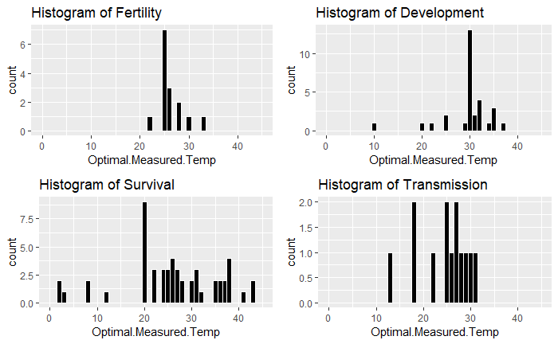

```r
result_set <- results
for(trait in unique(result_set$Broad.Trait)){
    res_sub <- subset(result_set, Broad.Trait == trait)
    plot <- ggplot(res_sub, aes(x = Optimal.Measured.Temp))
    plot <- plot + geom_histogram(binwidth = 1, colour = "White", fill = "Black") +  # geom_histogram(aes(y =..density..))
            ggtitle(paste("Histogram of", trait)) +
            xlim(0, 45)
    Dplot <- ggplot(res_sub, aes(x = Optimal.Measured.Temp))
    Dplot <- Dplot + geom_density() +
    ggtitle(paste("Density plot of", trait)) +
    xlim(0, 45)
    assign(paste("H_", trait, sep=""), plot)
    assign(paste("D_", trait, sep=""), Dplot)
}
# pdf("All Res Traits Optimal Measured.pdf")
grid.arrange(H_Fertility, H_Development, H_Survival, H_Transmission)
```

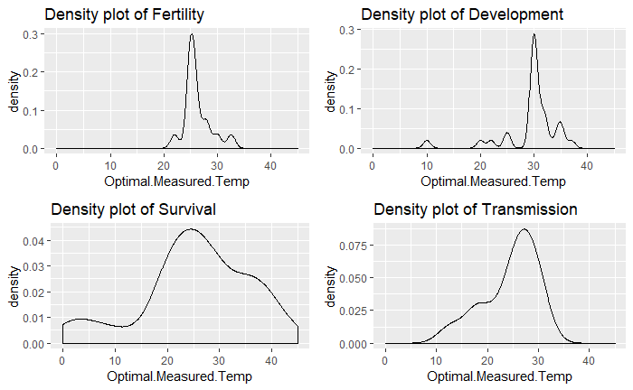

```r
grid.arrange(D_Fertility, D_Development, D_Survival, D_Transmission)
```

## 2.2 Density Plots of Measured Min, Max and Optimal Temperature for Four Broad Traits

Additional density plots but with the minimum and maximum temperatures added in. The temperatures are based on the measured temperature from experiment results.

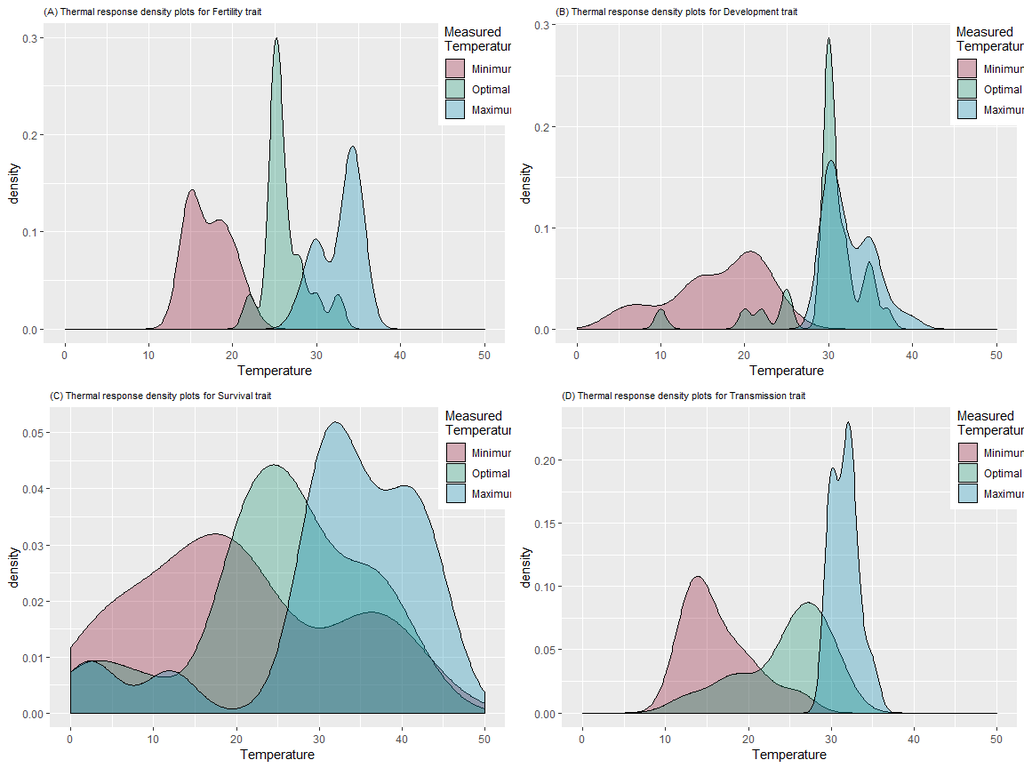

```r
# pdf("Trait Measured.pdf")
result_set <- results
count <- 1
alphabet <- c("(A)", "(B)", "(C)", "(D)")
for(trait in c("Fertility", "Development", "Survival", "Transmission")){
    res_sub <- subset(result_set, Broad.Trait == trait)
    res_plot <- stack(data.frame(res_sub$Min.Measured.Temp, res_sub$Optimal.Measured.Temp, res_sub$Max.Measured.Temp))
    leg_title <- "Measured\nTemperature"
    leg_names <- c("Minimum", "Optimal", "Maximum")
    leg_breaks <- c("res_sub.Min.Measured.Temp", "res_sub.Optimal.Measured.Temp", "res_sub.Max.Measured.Temp")
    plot <- ggplot(res_plot, aes(x = values))
    plot <- plot + geom_density(aes(group = ind, fill = ind), alpha = 0.3) +
            xlim(0, 50) +
            ggtitle(paste(alphabet[count], "Thermal response density plots for", trait, "trait")) +
            scale_fill_manual(values = c("#8A0829", "#088A68", "#0489B1"), name = leg_title, breaks = leg_breaks, labels = leg_names) +
            theme(legend.position = c(0.95, 0.85), plot.title = element_text(size = rel(0.75))) +
            xlab("Temperature")
    assign(paste("Mul_", trait, sep = ""), plot)
    count = count + 1
}
grid.arrange(Mul_Fertility, Mul_Development, Mul_Survival, Mul_Transmission)
```

### 2.2.1 MANOVA of Measured Trait

MANOVA test are performed to see if there is a statistically significant difference in the three key measures of temperature between the different areas.

```r
res_set <- results
y <- cbind(res_set$Min.Measured.Temp, res_set$Max.Measured.Temp, res_set$Optimal.Measured.Temp)
maov2 <- manova(y ~ Broad.Trait, data = res_set)
summary(maov2)
```

```
             Df  Pillai approx F num Df den Df  Pr(>F)
Broad.Trait   4 0.20636   2.0314     12    330 0.02117 *
Residuals   110
---
Signif. codes:  0 *** 0.001 ** 0.01 * 0.05 . 0.1   1
```

## 2.3 Density Plots of Estimated Min, Max and Optimal Temperature for Four Broad Traits

Density plots for the minimum, maximum and optimal temperature for the broad traits, in this case temperatures are derived from the best model for each set of traits data.

It only uses the models that are significant, i.e. the model is deemed to be an accurate reflection of the underlying pattern in the data.

The lack of significant results, mean that there is a lack of data for the density plots, hence it it not complete.

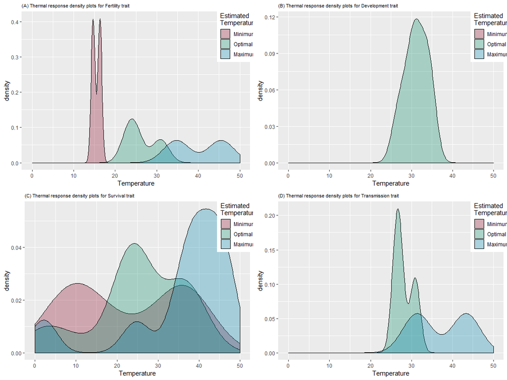

```r
# pdf("Trait Estimates.pdf")
result_set <- sig_results  # results, sig_results, mos_results, sig_mos_results
count <- 1
alphabet <- c("(A)", "(B)", "(C)", "(D)")
for(trait in c("Fertility", "Development", "Survival", "Transmission")){
    res_sub <- subset(result_set, Broad.Trait == trait)
    res_plot <- stack(data.frame(res_sub$Min.Estimated.Temp, res_sub$Optimal.Estimated.Temp, res_sub$Max.Estimated.Temp))
    leg_title <- "Estimated\nTemperature"
    leg_names <- c("Minimum", "Optimal", "Maximum")
    leg_breaks <- c("res_sub.Min.Estimated.Temp", "res_sub.Optimal.Estimated.Temp", "res_sub.Max.Estimated.Temp")
    plot <- ggplot(res_plot, aes(x = values))
    plot <- plot + geom_density(aes(group = ind, fill = ind), alpha = 0.3) +
            xlim(0, 50) +
            ggtitle(paste(alphabet[count], "Thermal response density plots for", trait, "trait")) +
            scale_fill_manual(values = c("#8A0829", "#088A68", "#0489B1"), name = leg_title, breaks = leg_breaks, labels = leg_names) +
            theme(legend.position = c(0.95, 0.85), plot.title = element_text(size = rel(0.75))) +
            xlab("Temperature")
    assign(paste("Mul_", trait, sep = ""), plot)
    count = count + 1
}
grid.arrange(Mul_Fertility, Mul_Development, Mul_Survival, Mul_Transmission)
```

### 2.3.1 MANOVA of Estimated Trait

MANOVA test are performed to see if there is a statistically significant difference in the three key measures of temperature between the different areas.

```r
res_set <- results
y <- cbind(res_set$Min.Estimated.Temp, res_set$Max.Estimated.Temp, res_set$Optimal.Estimated.Temp)
maov2 <- manova(y ~ Broad.Trait, data = res_set)
summary(maov2)
```

```
            Df  Pillai approx F num Df den Df  Pr(>F)
Broad.Trait  3 0.33562   2.2254      9    159 0.02297 *
Residuals   53
---
Signif. codes:  0 *** 0.001 ** 0.01 * 0.05 . 0.1   1
```

# 3 Exploring Temperature Response of Four Genera of Vectors

## 3.1 Density Plots of Measureed Min, Max and Optimal Temperature for For Types of Vectors

Aedes, Anopheles and Culex are three different genera of mosquitos. Whereas Glossina is a fly genus. The aim of this is to see if different genera of vectors have different ranges in operating temperature.

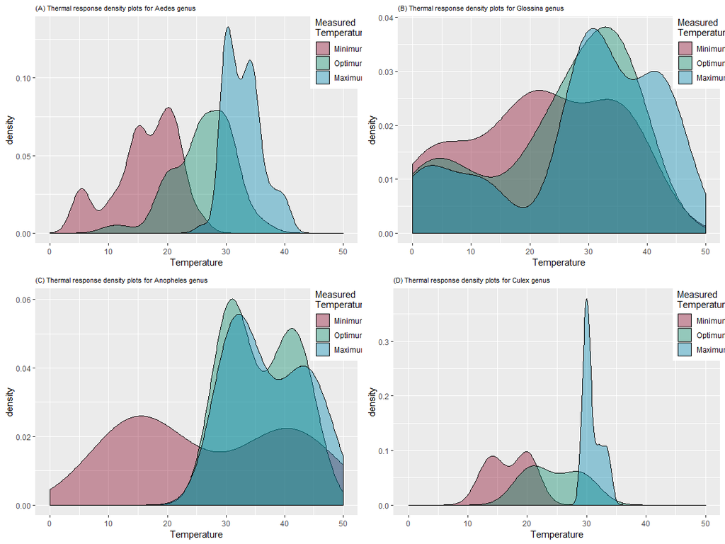

```r
# pdf("Genus Measured.pdf")
result_set <- results
count <- 1
alphabet <- c("(A)", "(B)", "(C)", "(D)")
for(genus in c("Aedes", "Glossina", "Anopheles", "Culex")){
    res_sub <- subset(result_set, Vector.Genus == genus)
    res_plot <- stack(data.frame(res_sub$Min.Measured.Temp, res_sub$Optimal.Measured.Temp, res_sub$Max.Measured.Temp))
    leg_title <- "Measured\nTemperature"
    leg_names <- c("Minimum", "Optimum", "Maximum")
    leg_breaks <- c("res_sub.Min.Measured.Temp", "res_sub.Optimal.Measured.Temp", "res_sub.Max.Measured.Temp")
    plot <- ggplot(res_plot, aes(x = values))
    plot <- plot + geom_density(aes(group = ind, fill = ind), alpha = 0.4) +
            xlim(0, 50) +
            ggtitle(paste(alphabet[count], "Thermal response density plots for", genus, "genus")) +
            scale_fill_manual(values = c("#8A0829", "#088A68", "#0489B1"), name = leg_title, breaks = leg_breaks, labels = leg_names) +
            theme(legend.position = c(0.95, 0.85), plot.title = element_text(size = rel(0.75))) +
            xlab("Temperature")
    assign(paste("Mul_", genus, sep = ""), plot)
    count = count + 1
}
grid.arrange(Mul_Aedes, Mul_Glossina, Mul_Anopheles, Mul_Culex)
```

### 3.1.1 MANOVA of Measured Genea

MANOVA test are performed to see if there is a statistically significant difference in the three key measures of temperature between the different areas.

```r
res_set <- results
y <- cbind(res_set$Min.Measured.Temp, res_set$Max.Measured.Temp, res_set$Optimal.Measured.Temp)
maov3 <- manova(y ~ Vector.Genus, data = res_set)
summary(maov3)
```

```
              Df  Pillai approx F num Df den Df   Pr(>F)
Vector.Genus   4 0.29627   3.0134     12    330 0.000499 ***
Residuals    110
---
Signif. codes:  0 *** 0.001 ** 0.01 * 0.05 . 0.1   1
```

## 3.2 Density Plots of Estimated Min, Max and Optimal Temperature for Four Types of Vectors

This uses the temperatures derived from the best model for each set of traits data, rather than their measured values. It only uses the models that are significant, i.e. the model is deemed to be an accurate reflection of the underlying pattern in the data. *Note: that there are no significant models for the Anopheles and Culux genera.*

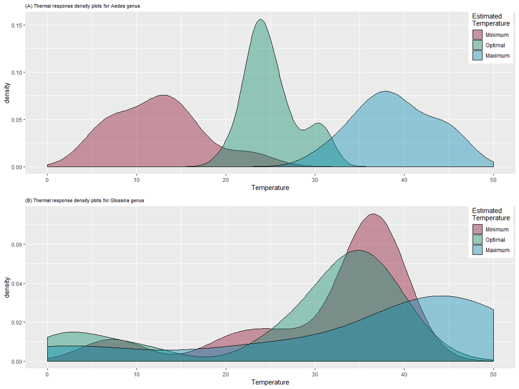

```r
# pdf("Genus Estimated.pdf")
result_set <- sig_results
count <- 1
alphabet <- c("(A)", "(B)", "(C)", "(D)")
for(genus in c("Aedes", "Glossina", "Anopheles", "Culex")){
    res_sub <- subset(result_set, Vector.Genus == genus)
    res_plot <- stack(data.frame(res_sub$Min.Estimated.Temp, res_sub$Optimal.Estimated.Temp, res_sub$Max.Estimated.Temp))
    leg_title <- "Estimated\nTemperature"
    leg_names <- c("Minimum", "Optimal", "Maximum")
    leg_breaks <- c("res_sub.Min.Estimated.Temp", "res_sub.Optimal.Estimated.Temp", "res_sub.Max.Estimated.Temp")
    plot <- ggplot(res_plot, aes(x = values))
    plot <- plot + geom_density(aes(group = ind, fill = ind), alpha = 0.4) +
            xlim(0, 50) +
            ggtitle(paste(alphabet[count], "Thermal response density plots for", genus, "genus")) +
            scale_fill_manual(values = c("#8A0829", "#088A68", "#0489B1"), name = leg_title, breaks = leg_breaks, labels = leg_names) +
            theme(legend.position = c(0.95, 0.85), plot.title = element_text(size = rel(0.75))) +
            xlab("Temperature")
    assign(paste("Mul_", genus, sep = ""), plot)
    count = count + 1
}
grid.arrange(Mul_Aedes, Mul_Glossina)
```

### 3.2.1 MANOVA of Estimated Genea

MANOVA test are performed to see if there is a statistically significant difference in the three key measures of temperature between the different areas.

```r
res_set <- results
y <- cbind(res_set$Min.Estimated.Temp, res_set$Max.Estimated.Temp, res_set$Optimal.Estimated.Temp)
maov3 <- manova(y ~ Vector.Genus, data = res_set)
summary(maov3)
```

```
             Df  Pillai approx F num Df den Df  Pr(>F)
Vector.Genus  4 0.43208   2.1874     12    156 0.01472 *
Residuals    52
---
Signif. codes:  0 *** 0.001 ** 0.01 * 0.05 . 0.1   1
```

# 4 Exploring Temperature Response of Different Species Within Genus

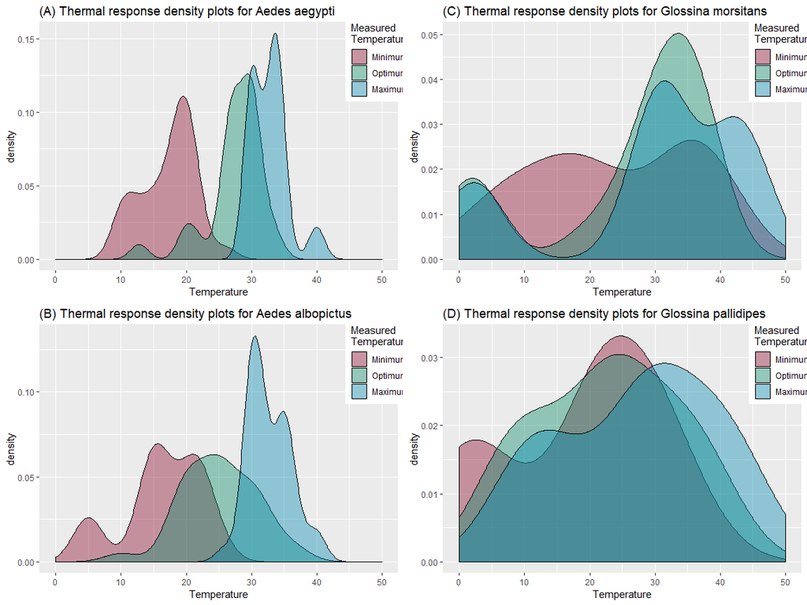

```r
# pdf("Species Measured.pdf")
result_set <- results
count <- 1
alphabet <- c("(A)", "(C)", "(B)", "(D)")
for(species in c("aegypti", "morsitans", "albopictus", "pallidipes")){
    res_sub <- subset(result_set, Vector.Species == species)
    res_plot <- stack(data.frame(res_sub$Min.Measured.Temp, res_sub$Optimal.Measured.Temp, res_sub$Max.Measured.Temp))
    leg_title <- "Measured\nTemperature"
    leg_names <- c("Minimum", "Optimum", "Maximum")
    leg_breaks <- c("res_sub.Min.Measured.Temp", "res_sub.Optimal.Measured.Temp", "res_sub.Max.Measured.Temp")
    plot <- ggplot(res_plot, aes(x = values))
    plot <- plot + geom_density(aes(group = ind, fill = ind), alpha = 0.4) +
            xlim(0, 50) +
            ggtitle(paste(alphabet[count], "Thermal response density plots for", res_sub$Vector.Genus, species)) +
            scale_fill_manual(values = c("#8A0829", "#088A68", "#0489B1"), name = leg_title, breaks = leg_breaks, labels = leg_names) +
            theme(legend.position = c(0.95, 0.85)) +
            xlab("Temperature")
    assign(paste("Mul_", species, sep = ""), plot)
    count = count + 1
}
grid.arrange(Mul_aegypti, Mul_morsitans, Mul_albopictus, Mul_pallidipes)
```

### 4.1.1 MANOVA of Aedes Measured

MANOVA test are performed to see if there is a statistically significant difference in the three key measures of temperature between the different areas.

```r
res_set <- results
res_set <- subset(results, Vector.Genus == "Aedes")
res_set_sig <- subset(res_set, p.value.for.F.stat < 0.05)
y1 <- cbind(res_set$Min.Measured.Temp, res_set$Max.Measured.Temp, res_set$Optimal.Measured.Temp)
maov1 <- manova(y1 ~ Vector.Species, data = res_set)
summary(maov1)
```

```
               Df  Pillai approx F num Df den Df Pr(>F)
Vector.Species  3 0.22697    1.637      9    180 0.1077
Residuals      60
```

This uses the temperatures derived from the best model for each set of traits data, rather than their measured values. It only uses the models that are significant, i.e. the model is deemed to be an accurate reflection of the underlying pattern in the data.

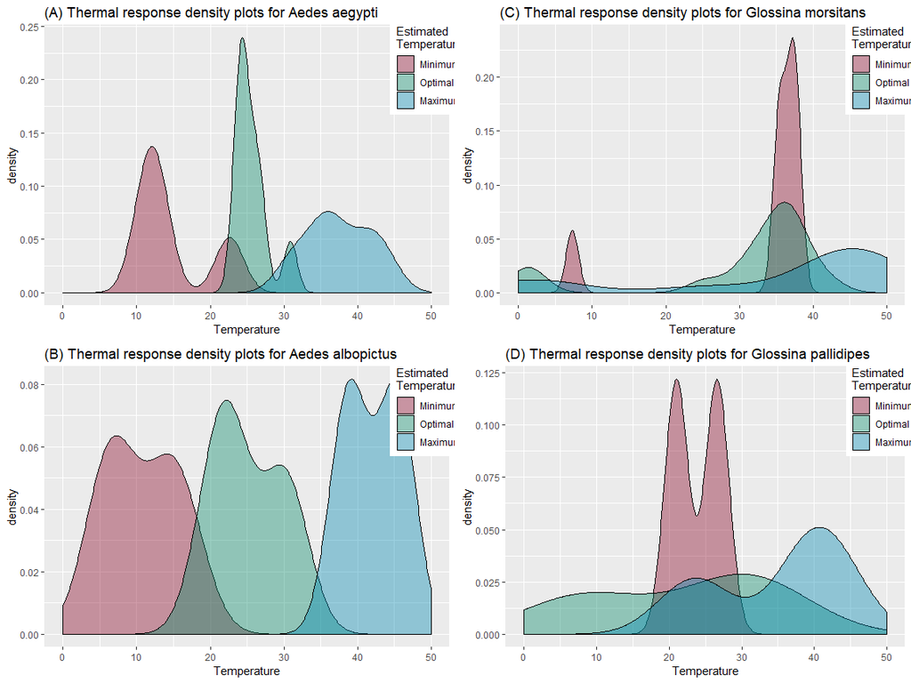

```r
# pdf("Species Estimated.pdf")
result_set <- sig_results
count <- 1
alphabet <- c("(A)", "(C)", "(B)", "(D)")
for(species in c("aegypti", "morsitans", "albopictus", "pallidipes")){
    res_sub <- subset(result_set, Vector.Species == species)
    res_plot <- stack(data.frame(res_sub$Min.Estimated.Temp, res_sub$Optimal.Estimated.Temp, res_sub$Max.Estimated.Temp))
    leg_title <- "Estimated\nTemperature"
    leg_names <- c("Minimum", "Optimal", "Maximum")
    leg_breaks <- c("res_sub.Min.Estimated.Temp", "res_sub.Optimal.Estimated.Temp", "res_sub.Max.Estimated.Temp")
    plot <- ggplot(res_plot, aes(x = values))
    plot <- plot + geom_density(aes(group = ind, fill = ind), alpha = 0.4) +
            xlim(0, 50) +
            ggtitle(paste(alphabet[count], "Thermal response density plots for", res_sub$Vector.Genus, species)) +
            scale_fill_manual(values = c("#8A0829", "#088A68", "#0489B1"), name = leg_title, breaks = leg_breaks, labels = leg_names) +
            theme(legend.position = c(0.95, 0.85)) +
            xlab("Temperature")
    assign(paste("Mul_", species, sep = ""), plot)
    count = count + 1
}
grid.arrange(Mul_aegypti, Mul_morsitans, Mul_albopictus, Mul_pallidipes)
```

### 4.2.1 MANOVA Test of Aedes Estimated

MANOVA test are performed to see if there is a statistically significant difference in the three key measures of temperature between the different areas.

```r
#manova species for Aedes
res_set <- results
res_set <- subset(results, Vector.Genus == "Aedes")
res_set_sig <- subset(res_set, p.value.for.F.stat < 0.05)
y2 <- cbind(res_set_sig$Min.Estimated.Temp, res_set_sig$Max.Estimated.Temp, res_set_sig$Optimal.Estimated.Temp)
maov2 <- manova(y2 ~ Vector.Species, data = res_set_sig)
summary(maov2)
```

```
               Df  Pillai approx F num Df den Df Pr(>F)
Vector.Species  3 0.49186  0.52295      9     24 0.8434
Residuals       8
```

# 5 Analysis of Data and Results Quality

```r
mean(subset(results$No..Data.Points, results$No..Data.Points < 31))
```

```
[1] 8.2
```

```r
mean(results$No..Unique.Temperatures)
```

```
[1] 6.865546
```

```r
mean(results$Range.Measured.Temp)
```

```
[1] 14.48501
```

```r
mean(results$Min.Measured.Temp)
```

```
[1] 17.64386
```

```r
mean(results$Max.Measured.Temp)
```

```
[1] 32.12887
```

plots used to analyse data quality

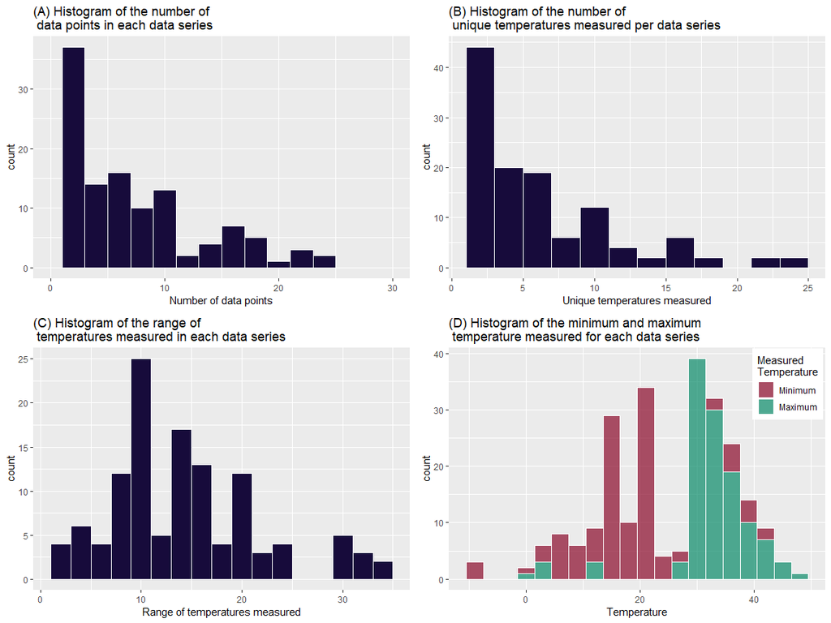

```r
# pdf("Data Quality Plots.pdf")
plot1 <- ggplot(results, aes(x = No..Data.Points))
plot1 <- plot1 + geom_histogram(binwidth = 2, colour = "White", fill = "#170B3B") +
        ggtitle(paste("(A) Histogram of the number of \n data points in each data series")) +
        xlim(0, 30) +
        xlab("Number of data points")
plot2 <- ggplot(results, aes(x = No..Unique.Temperatures))
plot2 <- plot2 + geom_histogram(binwidth = 2, colour = "White", fill = "#170B3B") +
        ggtitle(paste("(B) Histogram of the number of \n unique temperatures measured per data series")) +
        xlab("Unique temperatures measured")
plot3 <- ggplot(results, aes(x = Range.Measured.Temp))
plot3 <- plot3 + geom_histogram(binwidth = 2, colour = "White", fill = "#170B3B") +
        ggtitle(paste("(C) Histogram of the range of \n temperatures measured in each data series")) +
        xlab("Range of temperatures measured")
res_sub <- results
res_plot <- stack(data.frame(res_sub$Min.Measured.Temp, res_sub$Max.Measured.Temp))
leg_title <- "Measured\nTemperature"
leg_names <- c("Minimum", "Maximum")
leg_breaks <- c("res_sub.Min.Measured.Temp", "res_sub.Max.Measured.Temp")
plot4 <- ggplot(res_plot, aes(x = values))
plot4 <- plot4 + geom_histogram(binwidth = 3, colour = "White", aes(group = ind, fill = ind), alpha = 0.7) +
        ggtitle(paste("(D) Histogram of the minimum and maximum \n temperature measured for each data series")) +
        scale_fill_manual(values = c("#8A0829", "#088A68"), name = leg_title, breaks = leg_breaks, labels = leg_names) +
        theme(legend.position = c(0.9, 0.85)) +
        xlab("Temperature")
grid.arrange(plot1, plot2, plot3, plot4)
```